# Fun With Random Numbers: More Random Projection

2017-12-08 13:51:52 -0500

Last time, we learned about a method of dimensionality reduction called random projection. We showed that using random projection, the number of dimensions required to preserve the distance between the points in a set is dependent only upon the number of *points* in the set and the maximum acceptable distortion set by the user. Surprisingly it does *not* depend on the original number of dimensions. The proof that random projections work is hard to understand, but the method is very simple to implement in just a few steps. To reduce the dimensionality of a set of m points in an N dimensional space:

1. Get your data into a m × N matrix **D**
2. Choose your maximum allowable percent distortion ε
3. Calculate the number of dimensions for your reduced space, n = ln(m) / ε<sup>2</sup>.
4. Sample the entries of an N × n matrix from the standard normal distribution, **R**.
5. Multiply **D** by **R**.

Today we’re going to add a couple steps to this method and find another surprising result.

Let’s get some data. We’re going to work with the cities15000 dataset from geonames.org. Let’s download it, clean it up, and take a look…

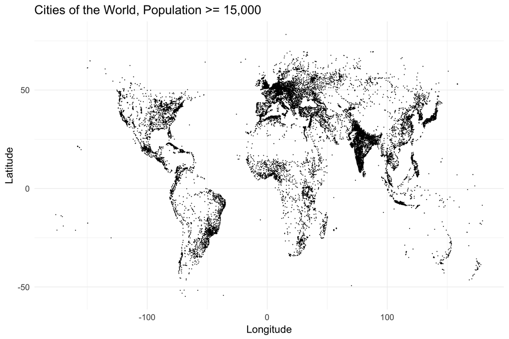

```r
if (!file.exists("~/cities15000.zip")) {
  download.file("http://download.geonames.org/export/dump/cities15000.zip", "~/cities15000.zip")
  unzip("~/cities15000.zip")
}

cities = readr::read_tsv("~/cities15000.txt",
                         col_names = FALSE,
                         col_types = "ccccccccccccccccccc",
                         quote = "") %>%
  transmute(Name = X2,
            Latitude = as.numeric(X5),
            Longitude = as.numeric(X6))

cities %>%
  ggplot(aes(Longitude, Latitude)) +
  geom_point(size = 0.25) +
  labs(title="Cities of the World, Population >= 15,000")
```

Lovely. Let’s get our data in order. We’ve got two dimensional points, and we’re going to randomly project them. Now this is weird. We’ve been talking about dimensionality *reduction* for the past post and a half, but this time we’re going to *increase* the dimensionality of our data using random projection. Don’t worry, everything’s gonna be fine. Let’s get our projection on.

```r
m = nrow(cities) #Number of points
N = 2            #Original Dimensionality
n = 32           #New Dimensionality

D = cities %>% select(Longitude, Latitude) %>% as.matrix()
R = matrix(rnorm(N * n, 0, 1), N, n) / sqrt(n)

projected = D %*% R
```

Everything is the same as before. We got the data in the data matrix, we sampled the random matrix, we multiplied. We’ve projected our 2 dimensional data up to 32 dimensions. Let’s take a look at one of these points in the projected space…

```r
projected[1,]
```

```
##  [1]  -9.69607775  10.25345270  -4.21077516   4.67312389   3.96554313
##  [6]  -3.67063793   1.13224839  -0.01171388  17.72590055  -4.64607227
## [11]   1.12650970   0.47144690  -3.68446208  -3.86907705  -0.02563179
## [16]   2.20474062  -0.98396074  -0.29861181 -13.51946298  -1.74291212
## [21] -10.89924932  -3.80656301  12.97949449  -4.47054957 -11.01206892
## [26]   1.23334790   2.39369960   8.69379098   5.10320807  11.22072014
## [31]  -6.19723050  14.79300758
```

OK, so each row in the projected matrix has 32 numbers. The next step in the process is to turn each row of 32 numbers into 32 bits using their signs. Positive numbers will map to 1s and negative numbers will map to 0s.

```r
projected_bits = matrix(as.numeric(projected >= 0), m, n) ##Compare with zero to get the sign of each number...
projected_bits[1,] ##And now we have 1s and 0s
```

```
##  [1] 0 1 0 1 1 0 1 0 1 0 1 1 0 0 0 1 0 0 0 0 0 0 1 0 0 1 1 1 1 1 0 1
```

Our projected data is now a collection of 32-bit strings. Let’s visualize the data. We’ll color the points on the original map by their projected bit strings

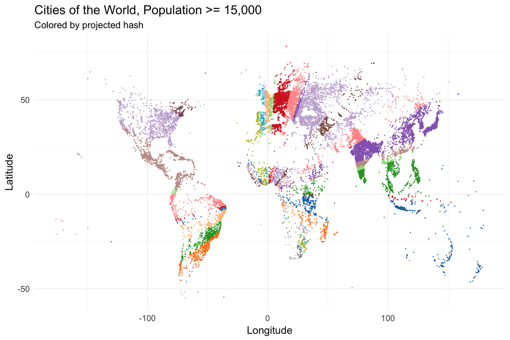

```r
cities_with_hashes = cities %>% bind_cols(Hash = apply(projected_bits, 1, paste0, collapse=""))
cities_with_hashes %>%
  ggplot(aes(Longitude, Latitude, color=Hash)) +
  geom_point(size = 0.5) +
  theme(legend.position = "none") +
  scale_color_manual(palette = jason_colors) +
  labs(title="Cities of the World, Population >= 15,000",
       subtitle="Colored by projected hash")
```

Sooo that’s interesting. It looks like there’s some radial symmetry going on. It’s a little hard to see though. Let’s fill in all the space to make it a bit more apparent…

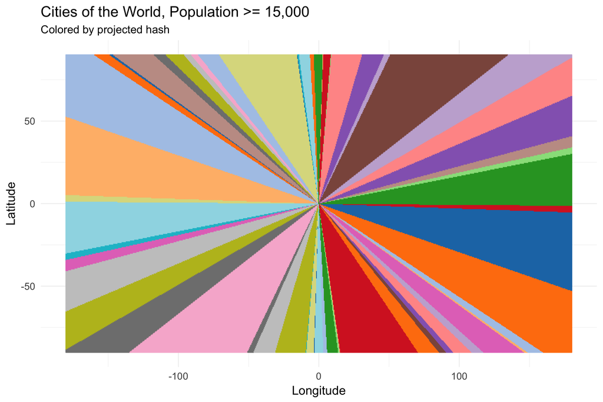

```r
all_space = crossing(Longitude = seq(-180, 180, .5),
                     Latitude = seq(-90, 90, .5))
all_space_projected = all_space %>% as.matrix() %*% R

all_space_projected_bits = matrix(as.numeric(all_space_projected >= 0), nrow(all_space), n)
all_space_with_hashes = all_space %>% bind_cols(Hash = apply(all_space_projected_bits, 1, paste0, collapse=""))

all_space_with_hashes %>%
  ggplot(aes(Longitude, Latitude, color=Hash)) +
  geom_point(size = 0.5) +
  theme(legend.position = "none") +
  scale_color_manual(palette = jason_colors) +
  labs(title="Cities of the World, Population >= 15,000",
       subtitle="Colored by projected hash")
```

There we go.

We’ve added one step to the previous random projection procedure and the result something very super ultra special called a **locality sensistive hash**.

These bit strings are very ultra super special, because they are **locality sensitive**.